# Retail Forecasting Project Report

ETC5550-Applied Forecasting-S1, 2023

Nishtha Arora (32296622)

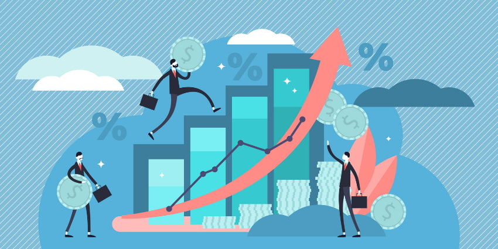

Objective: To forecast a real time series using ETS and ARIMA models.

```r
set.seed(32296622)
myseries <- aus_retail |>
  #sampling

  filter(!(`Series ID` %in% c("A3349561R","A3349883F","A3349499L","A3349902A",
                        "A3349588R","A3349763L","A3349372C","A3349450X",
                        "A3349679W","A3349378T","A3349767W","A3349451A"))) |>
  filter(`Series ID` == sample(`Series ID`,1)) #random series selected

#write.csv(myseries, "datamyseries.csv")
```

# 1 Statistical features of the original data.

The data set used is a subset of the *aus_retail* data which contain one numeric values, i.e. Turnover in $Million AUD. *aus_retail* is a part of *tsibbledata* package and can also be loaded with the package *fpp3* which contains total 9 packages including tsibbledata. The data is a time series of class *tsibble* and the source for the same is [Australian Bureau of Statistics, catalogue number 8501.0, table 11.](https://www.abs.gov.au/ausstats/abs@.nsf/exnote/8501.0)(Robjhyndman, n.d.).

```r
myseries
```

```
## # A tsibble: 441 x 5 [1M]
## # Key:       State, Industry [1]
##    State           Industry                        `Series ID`    Month Turnover
##    <chr>           <chr>                           <chr>          <mth>    <dbl>
##  1 South Australia Hardware, building and garden … A3349501L   1982 Apr      8.6
##  2 South Australia Hardware, building and garden … A3349501L   1982 May      9.5
##  3 South Australia Hardware, building and garden … A3349501L   1982 Jun      8.4
##  4 South Australia Hardware, building and garden … A3349501L   1982 Jul     10.3
##  5 South Australia Hardware, building and garden … A3349501L   1982 Aug     10.6
##  6 South Australia Hardware, building and garden … A3349501L   1982 Sep     11.5
##  7 South Australia Hardware, building and garden … A3349501L   1982 Oct     10.8
##  8 South Australia Hardware, building and garden … A3349501L   1982 Nov     13.1
##  9 South Australia Hardware, building and garden … A3349501L   1982 Dec     25.4
## 10 South Australia Hardware, building and garden … A3349501L   1983 Jan      9.2
## # ℹ 431 more rows
```

```r
interval(myseries)
```

```
## <interval[1]>
## [1] 1M
```

```r
myseries |>
  # mutate(year=year(Month)) |>
  index_by(Month) |>
  summarise(Total_turnover= mean(Turnover))
```

```
## # A tsibble: 441 x 2 [1M]
##       Month Total_turnover
##       <mth>          <dbl>
##  1 1982 Apr            8.6
##  2 1982 May            9.5
##  3 1982 Jun            8.4
##  4 1982 Jul           10.3
##  5 1982 Aug           10.6
##  6 1982 Sep           11.5
##  7 1982 Oct           10.8
##  8 1982 Nov           13.1
##  9 1982 Dec           25.4
## 10 1983 Jan            9.2
## # ℹ 431 more rows
```

```r
data_dict <- data.frame(
  S.No. = c("1", "2", "3", "4", "5"),
  Variables = c ("State", "Industry", "Series ID", "Month", "Turnover" ),
  DataType = c("Character", "Character", "Character", "Month", "Numeric"))


knitr::kable ( data_dict ,caption = "Data Dictonary") %>%
  kable_styling(latex_options = c("striped", "hold_position")) %>%
  kable_paper("hover", full_width = T) %>%
  scroll_box(width = "100%", height = "300px")
```

Table 1.1: Data Dictonary

| S.No. | Variables | DataType |
| --- | --- | --- |
| 1 | State | Character |
| 2 | Industry | Character |
| 3 | Series ID | Character |
| 4 | Month | Month |
| 5 | Turnover | Numeric |

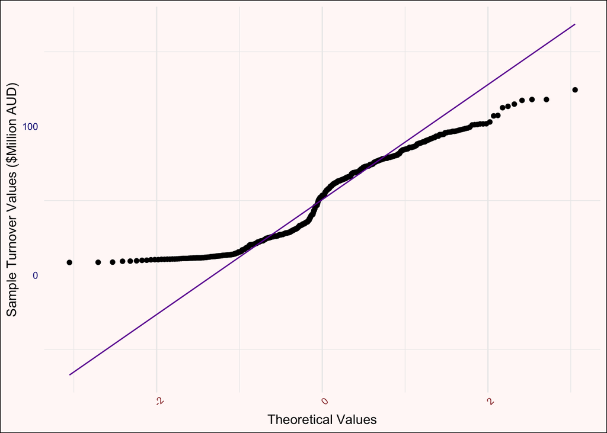

Figure 1.1: Quantile-Quantile Plot

```r
ggplot(myseries, aes(sample = Turnover)) +
  geom_qq() +
  geom_qq_line(color = "#6C03A0")+
  ylab("Sample Turnover Values ($Million AUD)")+
  xlab("Theoretical Values")+
  theme_minimal()+
   theme( plot.background = element_rect(fill = "#FFF8F7"),
    panel.grid.major.y = element_blank(),
      axis.text.x = element_text(color="#993333", angle=45, size=8),
    axis.text.y = element_text(colour= "#08007F", size=8))
```

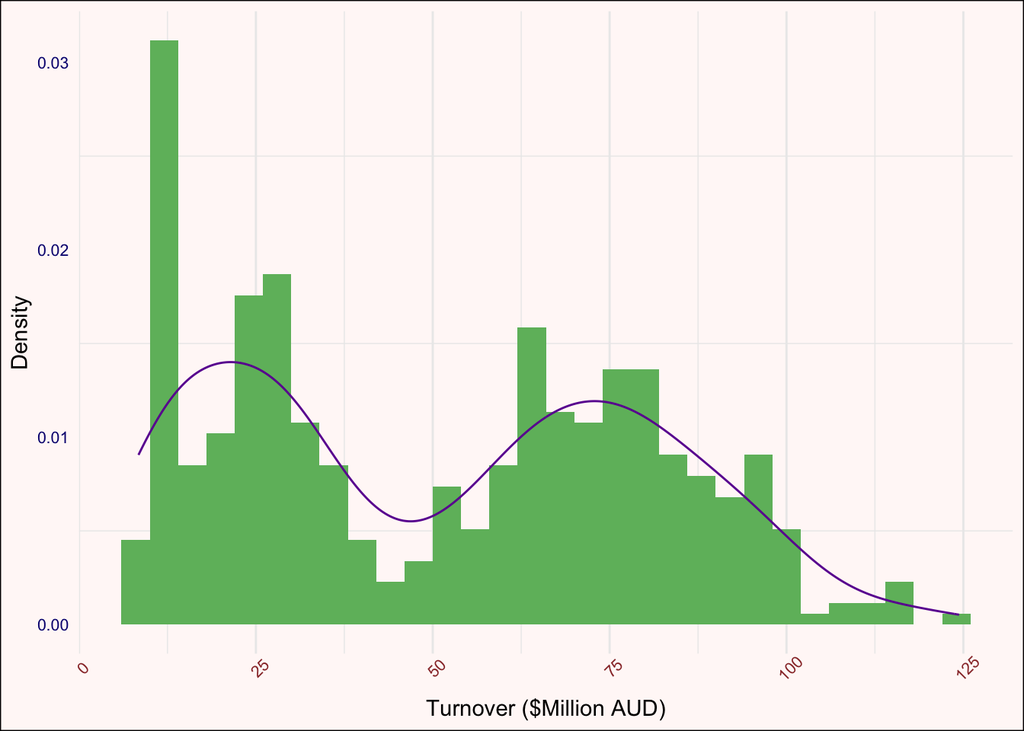

Figure 1.2: Distribution of Turnover

```r
  ggplot(myseries, aes(x=Turnover)) +
  geom_histogram(aes(y=after_stat(density)), fill = "#6EBA6B")+
  geom_density(color = "#6C03A0") +
  ylab("Density")+
  xlab("Turnover ($Million AUD)")+
  theme_minimal()+
   theme( plot.background = element_rect(fill = "#FFF8F7"),
    panel.grid.major.y = element_blank(),
        axis.text.x = element_text(color="#993333", angle=45, size=8),
    axis.text.y = element_text(colour= "#08007F", size=8))
```

```r
# ggplot(myseries, aes(x=Month, y=Turnover))+
#   geom_line()
```

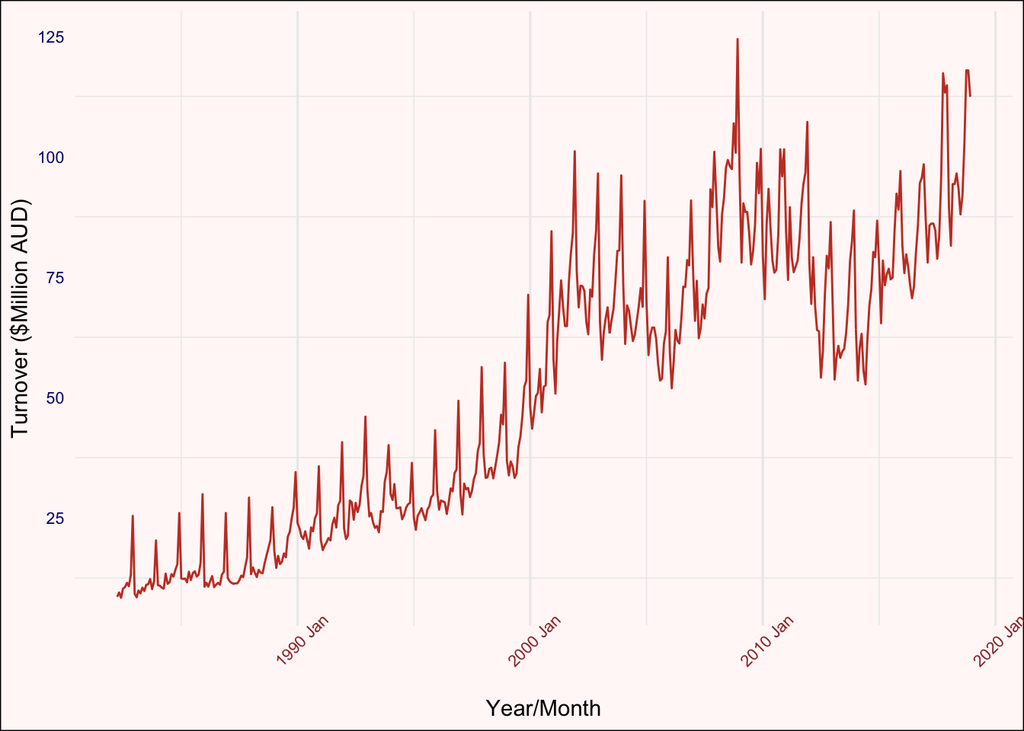

Figure 1.3: Time Series

```r
myseries |>
  autoplot(Turnover, color= "#C63F2C")+
  xlab("Year/Month")+
  ylab("Turnover ($Million AUD)")+
  theme_minimal()+
   theme( plot.background = element_rect(fill = "#FFF8F7"),
    panel.grid.major.y = element_blank(),
       axis.text.x = element_text(color="#993333", angle=45, size=8),
    axis.text.y = element_text(colour= "#08007F", size=8))
```

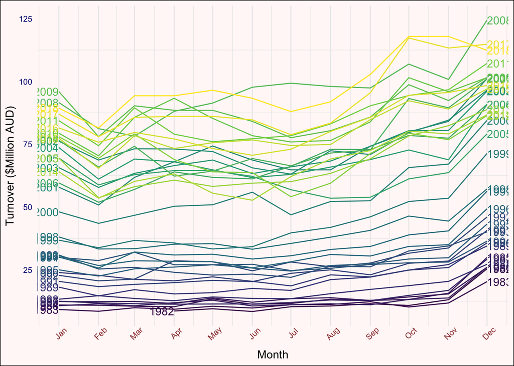

Figure 1.4: Seasonal Plot

```r
myseries |>
  gg_season(Turnover,
            labels = "both")+
  ylab("Turnover ($Million AUD)")+
   scale_colour_viridis_c()+
  theme_minimal()+
   theme( plot.background = element_rect(fill = "#FFF8F7"),
    panel.grid.major.y = element_blank(),
    axis.text.x = element_text(color="#993333", angle=45, size=8),
    axis.text.y = element_text(colour= "#08007F", size=8))
```

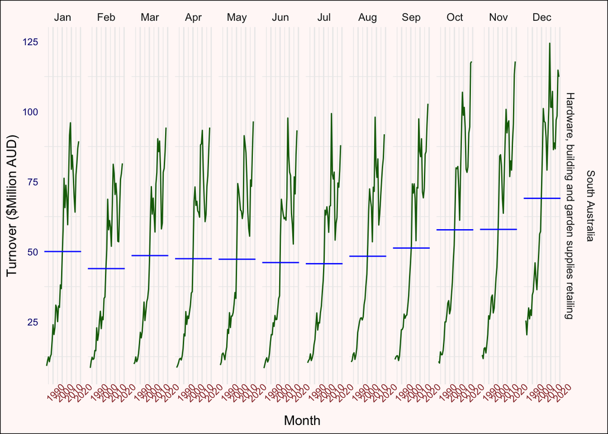

```r
myseries |>
  gg_subseries(Turnover, color= "#156A06")+
  ylab("Turnover ($Million AUD)")+
  theme_minimal()+
   theme( plot.background = element_rect(fill = "#FFF8F7"),
    panel.grid.major.y = element_blank(),
      axis.text.x = element_text(color="#993333", angle=45, size=8),
    axis.text.y = element_text(colour= "#08007F", size=8))
```